# Assignment1CameronHolland

### 1.) a.)

Taylor Series of f(x) = cos($\frac{x}{3}$) about $x_0 = \pi$:

T(x) = cos($\frac{\pi}{3}$) - $\frac{1}{3}\cdot$ sin($\frac{\pi}{3}$)(x-$\pi$) - $\frac{1}{2}\cdot \frac{1}{9}\cdot$ cos($\frac{\pi}{3}$)(x-$\pi$)$^2$ + $\frac{1}{6}\cdot \frac{1}{27}\cdot$ sin($\frac{\pi}{3}$)(x-$\pi$)$^3$ + $\frac{1}{24}\cdot \frac{1}{81}\cdot$ cos($\frac{\pi}{3}$)(x-$\pi$)$^4$ - $\frac{1}{120}\cdot \frac{1}{243}\cdot$ sin($\frac{\pi}{3}$)(x-$\pi$)$^5$ - ...

T(x) = cos($\frac{\pi}{3}$) - $\frac{1}{3}\cdot \frac{\sqrt{3}}{2}$(x-$\pi$) - $\frac{1}{18}\cdot \frac{1}{2}$(x-$\pi$)$^2$ + $\frac{1}{162}\cdot \frac{\sqrt{3}}{2}$(x-$\pi$)$^3$ + $\frac{1}{1944}\cdot \frac{1}{2}$(x-$\pi$)$^4$ - $\frac{1}{29160}\cdot \frac{\sqrt{3}}{2}$(x-$\pi$)$^5$ - ...

T(x) = cos($\frac{\pi}{3}$) - $\frac{\sqrt{3}}{6}$(x-$\pi$) - $\frac{1}{36}$(x-$\pi$)$^2$ + $\frac{\sqrt{3}}{324}$(x-$\pi$)$^3$ + $\frac{1}{3888}$(x-$\pi$)$^4$ - $\frac{\sqrt{3}}{58320}$(x-$\pi$)$^5$ - ...

### b.)

true = cos($\frac{1}{3}$) = 0.94495694631

est = 1 - $\frac{(\frac{1}{3})^2}{2!}$ + $\frac{(\frac{1}{3})^4}{4!}$ = 1 - $\frac{1}{18}$ + $\frac{1}{1944}$ = 0.94495884773

absolute error = $\lvert true - est\rvert$ = $\lvert0.94495694631 - 0.94495884773\rvert$ = 0.00000190142

relative error = $\lvert\frac{true - est}{true}\rvert$ = $\lvert\frac{0.94495694631 - 0.94495884773}{0.94495694631}\rvert$ = 0.00000201217

### c.)

b's absolute error = 1.901 x $10^{-6}$

b's relative error = 2.012 x $10^{-6}$

if $\hat{x}$ = 0.999, $\hat{f}(\hat{x})$ = 0.94506784876

absolute error = $\lvert0.94495884773 - 0.94506784876\rvert$ = 0.00010900103

relative error = $\lvert\frac{0.94495884773 - 0.94506784876}{0.94495884773}\rvert$ = 0.00011535002

### d.)

$\hat{f}(r)$ = cos($\frac{x}{3}$) - $\frac{1}{3}$ sin($\frac{x}{3}$)(r-x) - $\frac{1}{18}$ cos($\frac{x}{3}$)(r-x)$^2$

if r = x + h, using only the linear approximation gives:

$\hat{f}(x+h)$ = cos($\frac{x}{3}$) - $\frac{1}{3}$ sin($\frac{x}{3}$)(x + h - x) = cos($\frac{x}{3}$) - $\frac{1}{3}$ sin($\frac{x}{3}$)h$

absolute error: $\lvert f(x + h) - \hat{f}(x + h)\rvert = \lvert cos(\frac{x + h}{3}) - cos(\frac{x}{3}) - \frac{1}{3} sin(\frac{x}{3})h\rvert$

relative error: $\lvert \frac{f(x + h) - \hat{f}(x + h)}{f(x + h)}\rvert = \lvert \frac{cos(\frac{x + h}{3}) - cos(\frac{x}{3}) - \frac{1}{3} sin(\frac{x}{3})h}{cos(\frac{x + h}{3})}\rvert$

For h very small, I will approximate cos(x+h) = cos(x), so the approximated errors become:

absolute error: $\lvert cos(\frac{x}{3}) - cos(\frac{x}{3}) - \frac{1}{3} sin(\frac{x}{3})h\rvert = \lvert- \frac{1}{3} sin(\frac{x}{3})h\rvert$

relative error: $\lvert \frac{cos(\frac{x}{3}) - cos(\frac{x}{3}) - \frac{1}{3} sin(\frac{x}{3})h}{cos(\frac{x + h}{3})}\rvert = \lvert -\frac{1}{3} tan(\frac{x}{3})h\rvert$

### e.)

Condition of f(x), $\kappa = \lvert\frac{xf'(x)}{f(x)}\rvert = \lvert\frac{-xsin(\frac{x}{3})}{3cos(\frac{x}{3})}\rvert = -\frac{x}{3}tan(\frac{x}{3})$

### 2.) a.)

$f(x_0 + h) = f(x_0) + hf'(x_0) + \frac{h^2}{2}f''(x_0) + \frac{h^3}{3!}f'''(x_0) + ...$

$f(x_0 - h) = f(x_0) - hf'(x_0) + \frac{h^2}{2}f''(x_0) - \frac{h^3}{3!}f'''(x_0) + ...$

$f(x_0 + h) - f(x_0 - h) = 2hf'(x_0) + 2\frac{h^3}{3!}f'''(x_0) + ...$

$\frac{f(x_0 + h) - f(x_0 - h)}{2h} = f'(x_0) + \frac{h^2}{3!}f'''(x_0) + ...$

So an approximation for $f'(x_0) \text{is} \frac{f(x_0 + h) - f(x_0 - h)}{2h}$.

The associated in error in this approximation is $Error = \frac{h^2}{3!}f'''(x_0) + \frac{h^4}{5!}f^{(5)}(x_0) + ...$ which is O($h^2$)

### b.)

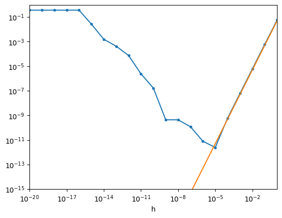

```python
import numpy as np
import matplotlib.pyplot as plt

def f(x):
    return np.sin(x)

def derivative(x):
    return np.cos(x)

x0 = 1.2
f0 = f(x0)
fp = derivative(x0)
h = np.logspace(-20,0,21)
err = abs(fp - (f(x0+h)-f(x0-h))/(2*h))

plt.plot(h,err,'.-')
plt.plot(h,0.05*h**2)
plt.axis([1e-20,1,1e-15,1e0])
plt.xlabel('h')
#plt.ylabel('err')
plt.yscale('log')
plt.xscale('log')
```

The graph of the central difference approximation is steeper against h as the error using this approximation is O(h^2), where as the error in the forward differences approximation is O(h). This algorithm begins to become inaccurate at h values of roughly 10 $^{-5}$. This is when the cancellation error of f(x+h) - f(x-h) begins to have a significant effect when multiplied by $\frac{1}{2h}$.

### 3.) a.)

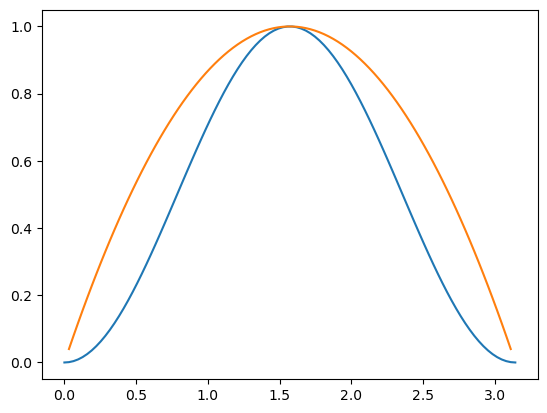

```python
def f(x):
    return(np.sin(x)**2)

xs = [0, np.pi/2, np.pi]
ys = f(xs)

w0 = 2/(np.pi**2)
w1 = -4/(np.pi**2)
w2 = 2/(np.pi**2)

def p(x):
    return [x*(x-xs[1])*(x-xs[2])*(ys[0]*w0/x + ys[1]*w1/(x-xs[1]) + ys[2]*w2/(x-xs[2])) for x in x]

xArr = np.linspace(0,np.pi,100)
plt.plot(xArr,f(xArr),'-')
xArr = [x for x in xArr if x not in xs]
plt.plot(xArr,p(xArr),'-')
plt.show()
```

### b.)

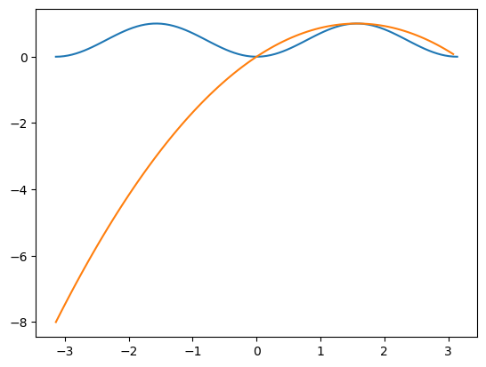

```python
xArrBigger = np.linspace(-np.pi,np.pi,100)
plt.plot(xArrBigger,f(xArrBigger),'-')
xArrBigger = [x for x in xArrBigger if x not in xs]
plt.plot(xArrBigger,p(xArrBigger),'-')
```

To improve this interpolation, I would add symmetric points, x = -x. This should help the curve come back up and down for increasingly negative xs.

In general, to improve an interpolation, add extra points where the interpolation is visually very different from the original function.

### 4.) a.)

Using Newton Bases,

$u(x) = (\gamma_0 + \gamma_1x + \gamma_2x^2)^{\frac{1}{2}}$

$v(x) = u(x)^2 = \gamma_0 + \gamma_1x + \gamma_2x^2$

$\phi_0 = 1, \phi_0 = (x-x_0), \phi_0 = (x-x_0)(x-x_1)$

$v(x) = y_0^2 + \frac{y_1^2 - y_0^2}{x_1-x_0}(x-x_0) + \frac{\frac{y_2^2 - y_1^2}{x_2 - x_1} - \gamma_1}{x_2 - x_0}(x-x_0)(x-x_1)$

$u(x) = \sqrt{v(x)} = \sqrt{y_0^2 + \frac{y_1^2 - y_0^2}{x_1-x_0}(x-x_0) + \frac{\frac{y_2^2 - y_1^2}{x_2 - x_1} - \gamma_1}{x_2 - x_0}(x-x_0)(x-x_1)}$

### b.)

```
C:\Users\Cameron Holland\AppData\Local\Temp\ipykernel_19380\3740751931.py:5: RuntimeWarning: invalid value encountered in sqrt
  return(np.sqrt(pts[0][1]**2 + gamma1*(x-pts[0][0]) + (((pts[2][1]**2 - pts[1][1]**2)/(pts[2][0] - pts[1][0]) - gamma1)/(pts[2][0] - pts[0][0]))*(x-pts[0][0])*(x-pts[1][0])))
```

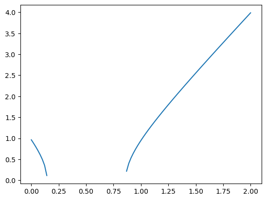

```python
pts = [(0.1,0.5), (1,1), (2,4)]

def u(x):
    gamma1 = (pts[1][1]**2 - pts[0][1]**2/(pts[1][0]-pts[0][0]))
    return(np.sqrt(pts[0][1]**2 + gamma1*(x-pts[0][0]) + (((pts[2][1]**2 - pts[1][1]**2)/(pts[2][0] - pts[1][0]) - gamma1)/(pts[2][0] - pts[0][0]))*(x-pts[0][0])*(x-pts[1][0])))

xArr = np.linspace(0,2,100)
plt.plot(xArr, u(xArr),'-')
plt.show()
```